# Optimal Treatment Analysis

## Outcome Variable

**Outcome Variable:** haz

## Predictor Variables

**Intervention Variable:** predfeed6

**Adjustment Set:**

- arm
- sex
- month
- brthmon
- W_mage
- meducyrs
- feducyrs
- hhwealth_quart
- hfoodsec
- W_mhtcm
- vagbrth
- W_gagebrth
- W_birthwt
- W_birthlen
- W_nrooms
- W_nchldlt5
- W_parity
- impfloor
- impsan
- safeh20
- delta_W_mage
- delta_meducyrs
- delta_feducyrs
- delta_hhwealth_quart
- delta_hfoodsec
- delta_W_mhtcm
- delta_vagbrth
- delta_W_gagebrth
- delta_W_birthwt
- delta_W_birthlen
- delta_W_nrooms
- delta_W_nchldlt5
- delta_W_parity
- delta_impfloor
- delta_impsan
- delta_safeh20

## Stratifying Variables

The analysis was stratified on these variable(s):

- agecat
- studyid
- country

## Data Summary

| agecat | studyid | country | predfeed6 | n_cell | n |
| --- | --- | --- | --- | --- | --- |
| Birth | ki0047075b-MAL-ED | BANGLADESH | 1 | 119 | 231 |
| Birth | ki0047075b-MAL-ED | BANGLADESH | 0 | 112 | 231 |
| Birth | ki0047075b-MAL-ED | BRAZIL | 1 | 27 | 175 |
| Birth | ki0047075b-MAL-ED | BRAZIL | 0 | 148 | 175 |
| Birth | ki0047075b-MAL-ED | INDIA | 1 | 15 | 190 |
| Birth | ki0047075b-MAL-ED | INDIA | 0 | 175 | 190 |
| Birth | ki0047075b-MAL-ED | NEPAL | 1 | 23 | 170 |
| Birth | ki0047075b-MAL-ED | NEPAL | 0 | 147 | 170 |
| Birth | ki0047075b-MAL-ED | PERU | 1 | 106 | 256 |
| Birth | ki0047075b-MAL-ED | PERU | 0 | 150 | 256 |
| Birth | ki0047075b-MAL-ED | SOUTH AFRICA | 1 | 3 | 211 |
| Birth | ki0047075b-MAL-ED | SOUTH AFRICA | 0 | 208 | 211 |
| Birth | ki0047075b-MAL-ED | TANZANIA, UNITED REPUBLIC OF | 1 | 1 | 119 |
| Birth | ki0047075b-MAL-ED | TANZANIA, UNITED REPUBLIC OF | 0 | 118 | 119 |
| Birth | ki1000109-EE | PAKISTAN | 1 | 1 | 2 |
| Birth | ki1000109-EE | PAKISTAN | 0 | 1 | 2 |
| Birth | kiGH5241-JiVitA-3 | BANGLADESH | 1 | 15096 | 19082 |
| Birth | kiGH5241-JiVitA-3 | BANGLADESH | 0 | 3986 | 19082 |
| Birth | kiGH5241-JiVitA-4 | BANGLADESH | 1 | 619 | 767 |
| Birth | kiGH5241-JiVitA-4 | BANGLADESH | 0 | 148 | 767 |
| 6 months | ki0047075b-MAL-ED | BANGLADESH | 1 | 123 | 235 |
| 6 months | ki0047075b-MAL-ED | BANGLADESH | 0 | 112 | 235 |
| 6 months | ki0047075b-MAL-ED | BRAZIL | 1 | 35 | 209 |
| 6 months | ki0047075b-MAL-ED | BRAZIL | 0 | 174 | 209 |
| 6 months | ki0047075b-MAL-ED | INDIA | 1 | 18 | 232 |
| 6 months | ki0047075b-MAL-ED | INDIA | 0 | 214 | 232 |
| 6 months | ki0047075b-MAL-ED | NEPAL | 1 | 29 | 235 |
| 6 months | ki0047075b-MAL-ED | NEPAL | 0 | 206 | 235 |
| 6 months | ki0047075b-MAL-ED | PERU | 1 | 113 | 269 |
| 6 months | ki0047075b-MAL-ED | PERU | 0 | 156 | 269 |
| 6 months | ki0047075b-MAL-ED | SOUTH AFRICA | 1 | 3 | 242 |
| 6 months | ki0047075b-MAL-ED | SOUTH AFRICA | 0 | 239 | 242 |
| 6 months | ki0047075b-MAL-ED | TANZANIA, UNITED REPUBLIC OF | 1 | 2 | 244 |
| 6 months | ki0047075b-MAL-ED | TANZANIA, UNITED REPUBLIC OF | 0 | 242 | 244 |
| 6 months | ki1000109-EE | PAKISTAN | 1 | 218 | 372 |
| 6 months | ki1000109-EE | PAKISTAN | 0 | 154 | 372 |
| 6 months | ki1000304b-SAS-FoodSuppl | INDIA | 1 | 0 | 168 |
| 6 months | ki1000304b-SAS-FoodSuppl | INDIA | 0 | 168 | 168 |
| 6 months | ki1113344-GMS-Nepal | NEPAL | 1 | 404 | 546 |
| 6 months | ki1113344-GMS-Nepal | NEPAL | 0 | 142 | 546 |
| 6 months | ki1148112-LCNI-5 | MALAWI | 1 | 47 | 272 |
| 6 months | ki1148112-LCNI-5 | MALAWI | 0 | 225 | 272 |
| 6 months | kiGH5241-JiVitA-3 | BANGLADESH | 1 | 13223 | 16682 |
| 6 months | kiGH5241-JiVitA-3 | BANGLADESH | 0 | 3459 | 16682 |
| 6 months | kiGH5241-JiVitA-4 | BANGLADESH | 1 | 3332 | 4259 |
| 6 months | kiGH5241-JiVitA-4 | BANGLADESH | 0 | 927 | 4259 |
| 24 months | ki0047075b-MAL-ED | BANGLADESH | 1 | 112 | 209 |
| 24 months | ki0047075b-MAL-ED | BANGLADESH | 0 | 97 | 209 |
| 24 months | ki0047075b-MAL-ED | BRAZIL | 1 | 29 | 169 |
| 24 months | ki0047075b-MAL-ED | BRAZIL | 0 | 140 | 169 |
| 24 months | ki0047075b-MAL-ED | INDIA | 1 | 17 | 224 |
| 24 months | ki0047075b-MAL-ED | INDIA | 0 | 207 | 224 |
| 24 months | ki0047075b-MAL-ED | NEPAL | 1 | 28 | 227 |
| 24 months | ki0047075b-MAL-ED | NEPAL | 0 | 199 | 227 |
| 24 months | ki0047075b-MAL-ED | PERU | 1 | 84 | 198 |
| 24 months | ki0047075b-MAL-ED | PERU | 0 | 114 | 198 |
| 24 months | ki0047075b-MAL-ED | SOUTH AFRICA | 1 | 3 | 227 |
| 24 months | ki0047075b-MAL-ED | SOUTH AFRICA | 0 | 224 | 227 |
| 24 months | ki0047075b-MAL-ED | TANZANIA, UNITED REPUBLIC OF | 1 | 2 | 212 |
| 24 months | ki0047075b-MAL-ED | TANZANIA, UNITED REPUBLIC OF | 0 | 210 | 212 |
| 24 months | ki1113344-GMS-Nepal | NEPAL | 1 | 360 | 480 |
| 24 months | ki1113344-GMS-Nepal | NEPAL | 0 | 120 | 480 |
| 24 months | ki1148112-LCNI-5 | MALAWI | 1 | 34 | 189 |
| 24 months | ki1148112-LCNI-5 | MALAWI | 0 | 155 | 189 |
| 24 months | kiGH5241-JiVitA-3 | BANGLADESH | 1 | 6677 | 8542 |
| 24 months | kiGH5241-JiVitA-3 | BANGLADESH | 0 | 1865 | 8542 |
| 24 months | kiGH5241-JiVitA-4 | BANGLADESH | 1 | 3289 | 4174 |
| 24 months | kiGH5241-JiVitA-4 | BANGLADESH | 0 | 885 | 4174 |

The following strata were considered:

- agecat: 24 months, studyid: ki0047075b-MAL-ED, country: BANGLADESH
- agecat: 24 months, studyid: ki0047075b-MAL-ED, country: BRAZIL
- agecat: 24 months, studyid: ki0047075b-MAL-ED, country: INDIA
- agecat: 24 months, studyid: ki0047075b-MAL-ED, country: NEPAL
- agecat: 24 months, studyid: ki0047075b-MAL-ED, country: PERU
- agecat: 24 months, studyid: ki0047075b-MAL-ED, country: SOUTH AFRICA
- agecat: 24 months, studyid: ki0047075b-MAL-ED, country: TANZANIA, UNITED REPUBLIC OF
- agecat: 24 months, studyid: ki1113344-GMS-Nepal, country: NEPAL
- agecat: 24 months, studyid: ki1148112-LCNI-5, country: MALAWI
- agecat: 24 months, studyid: kiGH5241-JiVitA-3, country: BANGLADESH
- agecat: 24 months, studyid: kiGH5241-JiVitA-4, country: BANGLADESH
- agecat: 6 months, studyid: ki0047075b-MAL-ED, country: BANGLADESH
- agecat: 6 months, studyid: ki0047075b-MAL-ED, country: BRAZIL
- agecat: 6 months, studyid: ki0047075b-MAL-ED, country: INDIA
- agecat: 6 months, studyid: ki0047075b-MAL-ED, country: NEPAL
- agecat: 6 months, studyid: ki0047075b-MAL-ED, country: PERU
- agecat: 6 months, studyid: ki0047075b-MAL-ED, country: SOUTH AFRICA
- agecat: 6 months, studyid: ki0047075b-MAL-ED, country: TANZANIA, UNITED REPUBLIC OF
- agecat: 6 months, studyid: ki1000109-EE, country: PAKISTAN
- agecat: 6 months, studyid: ki1000304b-SAS-FoodSuppl, country: INDIA
- agecat: 6 months, studyid: ki1113344-GMS-Nepal, country: NEPAL
- agecat: 6 months, studyid: ki1148112-LCNI-5, country: MALAWI
- agecat: 6 months, studyid: kiGH5241-JiVitA-3, country: BANGLADESH
- agecat: 6 months, studyid: kiGH5241-JiVitA-4, country: BANGLADESH
- agecat: Birth, studyid: ki0047075b-MAL-ED, country: BANGLADESH
- agecat: Birth, studyid: ki0047075b-MAL-ED, country: BRAZIL
- agecat: Birth, studyid: ki0047075b-MAL-ED, country: INDIA
- agecat: Birth, studyid: ki0047075b-MAL-ED, country: NEPAL
- agecat: Birth, studyid: ki0047075b-MAL-ED, country: PERU
- agecat: Birth, studyid: ki0047075b-MAL-ED, country: SOUTH AFRICA
- agecat: Birth, studyid: ki0047075b-MAL-ED, country: TANZANIA, UNITED REPUBLIC OF
- agecat: Birth, studyid: ki1000109-EE, country: PAKISTAN
- agecat: Birth, studyid: kiGH5241-JiVitA-3, country: BANGLADESH
- agecat: Birth, studyid: kiGH5241-JiVitA-4, country: BANGLADESH

### Dropped Strata

Some strata were dropped due to rare outcomes:

- agecat: Birth, studyid: ki0047075b-MAL-ED, country: SOUTH AFRICA
- agecat: Birth, studyid: ki0047075b-MAL-ED, country: TANZANIA, UNITED REPUBLIC OF
- agecat: Birth, studyid: ki1000109-EE, country: PAKISTAN
- agecat: 6 months, studyid: ki0047075b-MAL-ED, country: SOUTH AFRICA
- agecat: 6 months, studyid: ki0047075b-MAL-ED, country: TANZANIA, UNITED REPUBLIC OF
- agecat: 6 months, studyid: ki1000304b-SAS-FoodSuppl, country: INDIA
- agecat: 24 months, studyid: ki0047075b-MAL-ED, country: SOUTH AFRICA
- agecat: 24 months, studyid: ki0047075b-MAL-ED, country: TANZANIA, UNITED REPUBLIC OF

## Methods Detail

We’re interested in the causal parameters $E[Y_a]$ for all values of $a \in \mathcal{A}$. These parameters represent the mean outcome if, possibly contrary to fact, we intervened to set all units to have $A=a$. Under the randomization and positivity assumptions, these are identified by the statistical parameters $\psi_a=E_W[E_{Y|A,W}(Y|A=a,W)]$. In addition, we’re interested in the mean of $Y$, $E[Y]$ under no intervention (the observed mean). We will estimate these parameters by using SuperLearner to fit the relevant likelihood factors – $E_{Y|A,W}(Y|A=a,W)$ and $p(A=a|W)$, and then updating our likelihood fit using a joint TMLE.

For unadjusted analyses ($W=\{\}$), initial likelihoods were estimated using Lrnr_glm to estimate the simple $E(Y|A)$ and Lrnr_mean to estimate $p(A)$. For adjusted analyses, a small library containing Lrnr_glmnet, Lrnr_xgboost, and Lrnr_mean was used.

Having estimated these parameters, we will then use the delta method to estimate relative risks and attributable risks relative to a prespecified baseline level of $A$.

# Results Detail

## Results Plots

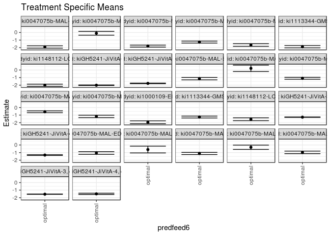

## Results Table

### Parameter: TSM

| agecat | studyid | country | intervention_level | baseline_level | estimate | ci_lower | ci_upper |
| --- | --- | --- | --- | --- | --- | --- | --- |
| Birth | ki0047075b-MAL-ED | BANGLADESH | optimal | observed | -1.0506111 | -1.2258488 | -0.8753735 |
| Birth | ki0047075b-MAL-ED | BRAZIL | optimal | observed | -0.5955224 | -1.0434703 | -0.1475744 |
| Birth | ki0047075b-MAL-ED | INDIA | optimal | observed | -1.1101204 | -1.2527154 | -0.9675254 |
| Birth | ki0047075b-MAL-ED | NEPAL | optimal | observed | -0.2965489 | -0.5800014 | -0.0130964 |
| Birth | ki0047075b-MAL-ED | PERU | optimal | observed | -0.9692964 | -1.1389472 | -0.7996455 |
| Birth | kiGH5241-JiVitA-3 | BANGLADESH | optimal | observed | -1.5365247 | -1.5569890 | -1.5160604 |
| Birth | kiGH5241-JiVitA-4 | BANGLADESH | optimal | observed | -1.4918496 | -1.5804586 | -1.4032407 |
| 6 months | ki0047075b-MAL-ED | BANGLADESH | optimal | observed | -1.1445749 | -1.3039329 | -0.9852170 |
| 6 months | ki0047075b-MAL-ED | BRAZIL | optimal | observed | 0.2205950 | -0.1983416 | 0.6395315 |
| 6 months | ki0047075b-MAL-ED | INDIA | optimal | observed | -1.0920619 | -1.2182053 | -0.9659185 |
| 6 months | ki0047075b-MAL-ED | NEPAL | optimal | observed | -0.5625621 | -0.6872572 | -0.4378670 |
| 6 months | ki0047075b-MAL-ED | PERU | optimal | observed | -1.1781347 | -1.3390743 | -1.0171950 |
| 6 months | ki1000109-EE | PAKISTAN | optimal | observed | -1.9442479 | -2.1332196 | -1.7552761 |
| 6 months | ki1113344-GMS-Nepal | NEPAL | optimal | observed | -1.2578689 | -1.3813614 | -1.1343765 |
| 6 months | ki1148112-LCNI-5 | MALAWI | optimal | observed | -1.5464528 | -1.7363771 | -1.3565285 |
| 6 months | kiGH5241-JiVitA-3 | BANGLADESH | optimal | observed | -1.2744013 | -1.2999986 | -1.2488040 |
| 6 months | kiGH5241-JiVitA-4 | BANGLADESH | optimal | observed | -1.3218775 | -1.3701774 | -1.2735775 |
| 24 months | ki0047075b-MAL-ED | BANGLADESH | optimal | observed | -1.9134167 | -2.0732728 | -1.7535607 |
| 24 months | ki0047075b-MAL-ED | BRAZIL | optimal | observed | -0.1007361 | -0.3501507 | 0.1486786 |
| 24 months | ki0047075b-MAL-ED | INDIA | optimal | observed | -1.7995287 | -1.9290784 | -1.6699790 |
| 24 months | ki0047075b-MAL-ED | NEPAL | optimal | observed | -1.2627845 | -1.3915594 | -1.1340096 |
| 24 months | ki0047075b-MAL-ED | PERU | optimal | observed | -1.6534179 | -1.8253321 | -1.4815038 |
| 24 months | ki1113344-GMS-Nepal | NEPAL | optimal | observed | -1.8761054 | -2.0268039 | -1.7254069 |
| 24 months | ki1148112-LCNI-5 | MALAWI | optimal | observed | -2.0127544 | -2.1603885 | -1.8651203 |
| 24 months | kiGH5241-JiVitA-3 | BANGLADESH | optimal | observed | -2.0078280 | -2.0405567 | -1.9750994 |
| 24 months | kiGH5241-JiVitA-4 | BANGLADESH | optimal | observed | -1.7654148 | -1.8075439 | -1.7232857 |

### Parameter: E(Y)

| agecat | studyid | country | intervention_level | baseline_level | estimate | ci_lower | ci_upper |
| --- | --- | --- | --- | --- | --- | --- | --- |
| Birth | ki0047075b-MAL-ED | BANGLADESH | observed | observed | -1.0317316 | -1.1618799 | -0.9015833 |
| Birth | ki0047075b-MAL-ED | BRAZIL | observed | observed | -0.7263429 | -0.8876385 | -0.5650472 |
| Birth | ki0047075b-MAL-ED | INDIA | observed | observed | -1.0250526 | -1.1724135 | -0.8776918 |
| Birth | ki0047075b-MAL-ED | NEPAL | observed | observed | -0.6964706 | -0.8552823 | -0.5376589 |
| Birth | ki0047075b-MAL-ED | PERU | observed | observed | -0.9311719 | -1.0458986 | -0.8164451 |
| Birth | kiGH5241-JiVitA-3 | BANGLADESH | observed | observed | -1.5502914 | -1.5696478 | -1.5309349 |
| Birth | kiGH5241-JiVitA-4 | BANGLADESH | observed | observed | -1.5207432 | -1.6058630 | -1.4356233 |
| 6 months | ki0047075b-MAL-ED | BANGLADESH | observed | observed | -1.2140355 | -1.3320337 | -1.0960372 |
| 6 months | ki0047075b-MAL-ED | BRAZIL | observed | observed | 0.0510207 | -0.0930194 | 0.1950608 |
| 6 months | ki0047075b-MAL-ED | INDIA | observed | observed | -1.2193606 | -1.3390323 | -1.0996890 |
| 6 months | ki0047075b-MAL-ED | NEPAL | observed | observed | -0.5595745 | -0.6727496 | -0.4463993 |
| 6 months | ki0047075b-MAL-ED | PERU | observed | observed | -1.3092999 | -1.4165606 | -1.2020392 |
| 6 months | ki1000109-EE | PAKISTAN | observed | observed | -2.2004704 | -2.3234073 | -2.0775336 |
| 6 months | ki1113344-GMS-Nepal | NEPAL | observed | observed | -1.3352045 | -1.4146382 | -1.2557708 |
| 6 months | ki1148112-LCNI-5 | MALAWI | observed | observed | -1.6395956 | -1.7592633 | -1.5199278 |
| 6 months | kiGH5241-JiVitA-3 | BANGLADESH | observed | observed | -1.3104400 | -1.3338132 | -1.2870668 |
| 6 months | kiGH5241-JiVitA-4 | BANGLADESH | observed | observed | -1.3574771 | -1.3964060 | -1.3185482 |
| 24 months | ki0047075b-MAL-ED | BANGLADESH | observed | observed | -1.9532775 | -2.0781247 | -1.8284303 |
| 24 months | ki0047075b-MAL-ED | BRAZIL | observed | observed | 0.0418343 | -0.1253834 | 0.2090521 |
| 24 months | ki0047075b-MAL-ED | INDIA | observed | observed | -1.8466071 | -1.9736347 | -1.7195796 |
| 24 months | ki0047075b-MAL-ED | NEPAL | observed | observed | -1.2744493 | -1.3952297 | -1.1536689 |
| 24 months | ki0047075b-MAL-ED | PERU | observed | observed | -1.7294949 | -1.8488722 | -1.6101177 |
| 24 months | ki1113344-GMS-Nepal | NEPAL | observed | observed | -1.8951389 | -1.9810871 | -1.8091907 |
| 24 months | ki1148112-LCNI-5 | MALAWI | observed | observed | -1.9605820 | -2.1001715 | -1.8209925 |
| 24 months | kiGH5241-JiVitA-3 | BANGLADESH | observed | observed | -2.0122091 | -2.0399540 | -1.9844641 |
| 24 months | kiGH5241-JiVitA-4 | BANGLADESH | observed | observed | -1.7762003 | -1.8148628 | -1.7375378 |

### Parameter: PAR

| agecat | studyid | country | intervention_level | baseline_level | estimate | ci_lower | ci_upper |
| --- | --- | --- | --- | --- | --- | --- | --- |
| Birth | ki0047075b-MAL-ED | BANGLADESH | optimal | observed | 0.0188795 | -0.1105972 | 0.1483563 |
| Birth | ki0047075b-MAL-ED | BRAZIL | optimal | observed | -0.1308205 | -0.5414006 | 0.2797596 |
| Birth | ki0047075b-MAL-ED | INDIA | optimal | observed | 0.0850677 | -0.0042008 | 0.1743363 |
| Birth | ki0047075b-MAL-ED | NEPAL | optimal | observed | -0.3999217 | -0.6738341 | -0.1260093 |
| Birth | ki0047075b-MAL-ED | PERU | optimal | observed | 0.0381245 | -0.0798959 | 0.1561449 |
| Birth | kiGH5241-JiVitA-3 | BANGLADESH | optimal | observed | -0.0137667 | -0.0214576 | -0.0060758 |
| Birth | kiGH5241-JiVitA-4 | BANGLADESH | optimal | observed | -0.0288935 | -0.0657050 | 0.0079180 |
| 6 months | ki0047075b-MAL-ED | BANGLADESH | optimal | observed | -0.0694605 | -0.1836832 | 0.0447622 |
| 6 months | ki0047075b-MAL-ED | BRAZIL | optimal | observed | -0.1695743 | -0.5438106 | 0.2046621 |
| 6 months | ki0047075b-MAL-ED | INDIA | optimal | observed | -0.1272987 | -0.2057252 | -0.0488723 |
| 6 months | ki0047075b-MAL-ED | NEPAL | optimal | observed | 0.0029877 | -0.0586177 | 0.0645931 |
| 6 months | ki0047075b-MAL-ED | PERU | optimal | observed | -0.1311652 | -0.2528243 | -0.0095061 |
| 6 months | ki1000109-EE | PAKISTAN | optimal | observed | -0.2562226 | -0.4015236 | -0.1109216 |
| 6 months | ki1113344-GMS-Nepal | NEPAL | optimal | observed | -0.0773356 | -0.1696158 | 0.0149446 |
| 6 months | ki1148112-LCNI-5 | MALAWI | optimal | observed | -0.0931428 | -0.2439070 | 0.0576214 |
| 6 months | kiGH5241-JiVitA-3 | BANGLADESH | optimal | observed | -0.0360387 | -0.0470740 | -0.0250034 |
| 6 months | kiGH5241-JiVitA-4 | BANGLADESH | optimal | observed | -0.0355996 | -0.0694169 | -0.0017823 |
| 24 months | ki0047075b-MAL-ED | BANGLADESH | optimal | observed | -0.0398608 | -0.1731216 | 0.0934000 |
| 24 months | ki0047075b-MAL-ED | BRAZIL | optimal | observed | 0.1425704 | -0.0495292 | 0.3346700 |
| 24 months | ki0047075b-MAL-ED | INDIA | optimal | observed | -0.0470784 | -0.0907293 | -0.0034276 |
| 24 months | ki0047075b-MAL-ED | NEPAL | optimal | observed | -0.0116648 | -0.0575824 | 0.0342528 |
| 24 months | ki0047075b-MAL-ED | PERU | optimal | observed | -0.0760770 | -0.2154875 | 0.0633334 |
| 24 months | ki1113344-GMS-Nepal | NEPAL | optimal | observed | -0.0190335 | -0.1424608 | 0.1043939 |
| 24 months | ki1148112-LCNI-5 | MALAWI | optimal | observed | 0.0521724 | -0.0868505 | 0.1911953 |
| 24 months | kiGH5241-JiVitA-3 | BANGLADESH | optimal | observed | -0.0043810 | -0.0234809 | 0.0147188 |
| 24 months | kiGH5241-JiVitA-4 | BANGLADESH | optimal | observed | -0.0107855 | -0.0287015 | 0.0071306 |